# Using the CalFluxTools Example Data

CalFluxTools provides a workflow for parsing, quality-controlling, visualizing, transforming, and analyzing calcium flux plate-reader data. It parses calcium flux data in the `statAll` format together with plate maps and a parameter manifest, organizes the data into plate and plate-set objects, applies processing rules such as masking, parameter filtering, categorical encoding, blank or missing-value replacement, and baseline-normalized transformations, and supports downstream outputs including data completeness reports, plate heatmaps, bar charts, z-prime factor summaries, PCA, and random-forest classification results.

This vignette walks through the analysis of example calcium flux files distributed with CalFluxTools. The package includes plate-reader output files in `statAll` format, matching plate maps, and Excel parameter manifests under `inst/extdata`.

## Run the Complete Workflow

With a properly formatted parameter manifest and the data files referenced by that manifest in place, **this is the only line of code needed to run the CalFluxTools workflow**:

```r
calflux_data <- CalFluxTools::processCalFluxData("path/to/parameter_manifest.xlsx")
```

`processCalFluxData()` reads the manifest, loads the specified `statAll` files and plate maps, organizes paired or unpaired plate reads, and applies the configured data-cleaning, filtering, transformation, and quality-control steps. It then runs the requested downstream analyses and writes their plots, tables, and reports to the configured output directory. The function also returns a `CalFluxData` object containing the loaded and processed plate data, analysis settings, transformed data, and analysis results.

The manifest is the control file for the entire workflow: it must identify the root and output locations, input data and plate-map files, parameters to use, and the processing and analysis options. Once the manifest and its referenced data are correctly formatted, no calls to the lower-level package functions are required.

```r
library(CalFluxTools)
library(ggplot2)
```

## Locate the Example Files

Use `system.file()` to locate packaged data after CalFluxTools has been installed. The helper below also works when knitting this vignette from the source tree.

```r
example_file <- function(...) {
  installed_path <- system.file("extdata", ..., package = "CalFluxTools")
  if (nzchar(installed_path)) {
    return(installed_path)
  }

  source_paths <- c(
    file.path("..", "inst", "extdata", ...),
    file.path("inst", "extdata", ...)
  )
  existing_paths <- source_paths[file.exists(source_paths)]
  if (length(existing_paths) > 0) {
    return(normalizePath(existing_paths[[1]], mustWork = TRUE))
  }

  stop("Could not locate CalFluxTools example data.")
}

simulated_dir <- example_file("Simulated_data")
stemonix_dir <- example_file("Stemonix_05_2022")

list.files(simulated_dir)
```

```
#> [1] "CalFlux_Parameter_selection_Control_PC3_New_T5.xlsx"
#> [2] "CalFluxData_Log_20260714_1711.log"
#> [3] "CalFluxData_Log_20260714_1715.log"
#> [4] "Control_Plate_map_1_PC3_New_T2.csv"
#> [5] "Control_plate1_Test1_30min_n001_Pro2_New_T1.statAll"
#> [6] "Control_plate1_Test1_BL_n001_Pro2_New_T1.statAll"
#> [7] "Updated_Control_PC3_New_T5_CalFluxData_Analysis_20260714_1715."
```

```r
list.files(stemonix_dir)
```

```
#> [1] "05272022_Stemonix_plate3_60mins_n001_Pro2.statAll"
#> [2] "05272022_Stemonix_plate3_BL_n001_Pro2.statAll"
#> [3] "CalFlux_Parameter_selection_MOE9_60_PC.xlsx"
#> [4] "Stemonix_MOE9_60_PC_ON2_Full.csv"
```

The simulated dataset contains one baseline read, one post-dose read, one plate map, and one manifest describing the intended analysis parameters. This enables us to use the “paired analysis” pipeline provided by the package.

```r
baseline_file <- example_file(
  "Simulated_data",
  "Control_plate1_Test1_BL_n001_Pro2_New_T1.statAll"
)
postdose_file <- example_file(
  "Simulated_data",
  "Control_plate1_Test1_30min_n001_Pro2_New_T1.statAll"
)
plate_map_file <- example_file(
  "Simulated_data",
  "Control_Plate_map_1_PC3_New_T2.csv"
)
parameter_file <- example_file(
  "Simulated_data",
  "CalFlux_Parameter_selection_Control_PC3_New_T5.xlsx"
)
```

## Inspect the Parameter Manifest

The manifest stores analysis settings and per-parameter processing rules. The copy currently included with this source tree records the original development root directory, so the low-level examples below read the files directly from `inst/extdata`.

```r
analysis_settings <- openxlsx::read.xlsx(
  parameter_file,
  sheet = "Analysis_Settings",
  colNames = FALSE
)
analysis_settings <- analysis_settings[!is.na(analysis_settings$X1), ]

knitr::kable(
  analysis_settings[, c("X1", "X2", "X3", "X4", "X5")],
  col.names = c("Setting", "Value", "Value 2", "Value 3", "Value 4")
)
```

| Setting | Value | Value 2 | Value 3 | Value 4 |
| --- | --- | --- | --- | --- |
| Analysis_Name | Updated_Control_PC3_New_T5 | NA | NA | NA |
| Root_Directory | /Users/pattac/Desktop/aso_dev/Updated_Simulated_Data_Files | NA | NA | NA |
| Plate_Format | 384 | NA | NA | NA |
| Plate_File_Pairs | NA | NA | NA | NA |
| Plate_Label | File | Plate_Map | Plate_Pair | Output Dir |
| Ref_for_Post-Dose Timepoint | Control_plate1_Test1_BL_n001_Pro2_New_T1.statAll | Control_Plate_map_1_PC3_New_T2.csv | 1 | Post-Dose Timepoint |
| Post-Dose Timepoint | Control_plate1_Test1_30min_n001_Pro2_New_T1.statAll | Control_Plate_map_1_PC3_New_T2.csv | 1 | Post-Dose Timepoint |
| Processing | NA | NA | NA | NA |
| Paired_Analysis | TRUE | NA | NA | NA |
| Median_Background_Correction | FALSE | NA | NA | NA |
| Imputation_Method | per_param_pct_min | NA | NA | NA |
| Imputation_Fraction_Min | 0.01 | NA | NA | NA |
| Transformation | log2ratio | (log2ratio, pct_control) | NA | NA |
| Export_QC_PDF | TRUE | NA | NA | NA |
| Export_Data_Dropout_Table | TRUE | NA | NA | NA |
| Export_Transformed_Averages_and_SD | TRUE | NA | NA | NA |
| Stat | Paired_t_Test | NA | NA | NA |
| Negative_Control_Key | Negative Control | NA | NA | NA |
| Positive_Control_Key | Positive Control | NA | NA | NA |
| Test_Sample_Key | Test | NA | NA | NA |

```r
parameter_info <- openxlsx::read.xlsx(parameter_file, sheet = "Parameter_Info")
knitr::kable(head(parameter_info[, c("Statistic", "Suggested_Abbreviation", "Use")]))
```

| Statistic | Suggested_Abbreviation | Use |
| --- | --- | --- |
| Mean Peak Amplitude (RFU) | PkAmp | 1 |
| Peak Amplitude S.D. (RFU) | PkAmp_SD | 1 |
| Number of Peaks | PkCt | 1 |
| Mean Peak Rate (PpM) | PkRate | 1 |
| Peak Rate S.D. (PpM) | PkRate_SD | 0 |
| Peak Spacing (s) | PkSp | 1 |

If you want to run the full wrapper from this example data, first create a new manifest that points at the installed `extdata` directory and the filenames distributed with the package.

```r
patched_parameter_file <- tempfile(fileext = ".xlsx")
file.copy(parameter_file, patched_parameter_file, overwrite = TRUE)

manifest <- openxlsx::loadWorkbook(patched_parameter_file)
settings <- openxlsx::read.xlsx(
  patched_parameter_file,
  sheet = "Analysis_Settings",
  colNames = FALSE
)

settings[settings$X1 == "Root_Directory", "X2"] <- paste0(
  normalizePath(simulated_dir),
  .Platform$file.sep
)
settings[
  settings$X1 == "Control_plate1_Test1_BL_n001_Pro2_New_T1.statAll",
  "X2"
] <- "Control_plate1_Test1_BL_n001_Pro2_New_T1.statAll"
settings[
  settings$X1 == "Control_plate1_Test1_30min_n001_Pro2_New_T1.statAll",
  "X2"
] <- "Control_plate1_Test1_30min_n001_Pro2_New_T1.statAll"

openxlsx::writeData(
  manifest,
  sheet = "Analysis_Settings",
  x = settings,
  colNames = FALSE
)
openxlsx::saveWorkbook(manifest, patched_parameter_file, overwrite = TRUE)

calflux_data <- processCalFluxData(patched_parameter_file)
```

Although it is easiest to run the package using the `processCalFluxData` function, lower-level functions are also available for data parsing, transformation and visualization.

## Parse Plate Reads

Use `read_calflux_data()` to parse each `statAll` file into a `plate` S4 object. The metadata reader used by the package is currently internal, so this example uses `CalFluxTools:::` to attach the plate map in the same way as the analysis wrapper.

```r
baseline_plate <- read_calflux_data(baseline_file)
postdose_plate <- read_calflux_data(postdose_file)

baseline_plate <- CalFluxTools:::read_calflux_metadata(
  plate_map_file,
  baseline_plate
)
postdose_plate <- CalFluxTools:::read_calflux_metadata(
  plate_map_file,
  postdose_plate
)

plate_summary <- data.frame(
  read = c("Baseline", "Post-dose"),
  plate_id = c(baseline_plate@plateId, postdose_plate@plateId),
  wells = c(length(baseline_plate@wellIds), length(postdose_plate@wellIds)),
  parameters = c(length(baseline_plate@parameters), length(postdose_plate@parameters))
)
knitr::kable(plate_summary)
```

[output not shown]

The plate map provides the well-level sample annotations used for masking, controls, test samples, concentrations, and plotting.

```r
plate_map <- baseline_plate@plateAnnotMap

well_type_summary <- as.data.frame(table(plate_map$WellType))
names(well_type_summary) <- c("WellType", "Wells")
knitr::kable(well_type_summary)
```

| WellType | Wells |
| --- | --- |
| Empty | 325 |
| Negative Control | 5 |
| Positive Control | 6 |
| Test | 48 |

```r
compound_summary <- aggregate(
  Well ~ Compound + WellType,
  data = plate_map,
  FUN = length
)
names(compound_summary)[names(compound_summary) == "Well"] <- "Wells"
compound_summary <- compound_summary[
  order(compound_summary$WellType, compound_summary$Compound),
]
knitr::kable(head(compound_summary, 12))
```

| Compound | WellType | Wells |
| --- | --- | --- |
| Empty | Empty | 307 |
| PC1 | Empty | 6 |
| PC2 | Empty | 6 |
| PC4 | Empty | 6 |
| Veh | Negative Control | 5 |
| PC3 | Positive Control | 6 |
| Non-Toxic#1 | Test | 24 |
| Toxic#1 | Test | 24 |

## Check Data Completeness

`missingDataReport()` summarizes missing, blank, empty, masked, and usable wells per parameter. `calculateParamCV()` provides a quick coefficient of variation screen on the same plate object.

```r
missing_report <- missingDataReport(baseline_plate)
missing_report <- missing_report[
  order(missing_report$Missing_Count, decreasing = TRUE),
]
knitr::kable(head(missing_report, 10))
```

|  | Parameter | Well_Count | Empty_Wells | Masked_Wells | Keeper_Wells | NA_Count | Blank_Count | Missing_Count | Good_Count |
| --- | --- | --- | --- | --- | --- | --- | --- | --- | --- |
| Mean EAD-like peak Rate (PpM) | Mean EAD-like peak Rate (PpM) | 384 | 0 | 0 | 384 | 384 | 0 | 384 | 0 |
| EAD-like peak Rate S.D. (PpM) | EAD-like peak Rate S.D. (PpM) | 384 | 0 | 0 | 384 | 384 | 0 | 384 | 0 |
| Number of EAD-like peaks S.D. | Number of EAD-like peaks S.D. | 384 | 0 | 0 | 384 | 384 | 0 | 384 | 0 |
| Mean Peak Amplitude (RFU) | Mean Peak Amplitude (RFU) | 384 | 0 | 0 | 384 | 0 | 0 | 0 | 384 |
| Peak Amplitude S.D. (RFU) | Peak Amplitude S.D. (RFU) | 384 | 0 | 0 | 384 | 0 | 0 | 0 | 384 |
| Number of Peaks | Number of Peaks | 384 | 0 | 0 | 384 | 0 | 0 | 0 | 384 |
| Mean Peak Rate (PpM) | Mean Peak Rate (PpM) | 384 | 0 | 0 | 384 | 0 | 0 | 0 | 384 |
| Peak Rate S.D. (PpM) | Peak Rate S.D. (PpM) | 384 | 0 | 0 | 384 | 0 | 0 | 0 | 384 |
| Peak Spacing (s) | Peak Spacing (s) | 384 | 0 | 0 | 384 | 0 | 0 | 0 | 384 |
| Peak Spacing S.D. (s) | Peak Spacing S.D. (s) | 384 | 0 | 0 | 384 | 0 | 0 | 0 | 384 |

```r
cv_report <- calculateParamCV(baseline_plate)
cv_report <- cv_report[order(cv_report$CV, decreasing = TRUE, na.last = TRUE), ]
knitr::kable(head(cv_report, 10))
```

|  | Parameter | CV |
| --- | --- | --- |
| Number of EAD-like peaks per well | Number of EAD-like peaks per well | 161.18996 |
| Mean Number of EAD-like peaks | Mean Number of EAD-like peaks | 147.46672 |
| Peak Rate S.D. (PpM) | Peak Rate S.D. (PpM) | 59.28361 |
| Decay time S.D. (s) | Decay time S.D. (s) | 41.36705 |
| Linear time to % of peak S.D. (RFU/s) | Linear time to % of peak S.D. (RFU/s) | 40.57299 |
| Rise time S.D. (s) | Rise time S.D. (s) | 39.88877 |
| Decay slope S.D. (RFU/s) | Decay slope S.D. (RFU/s) | 20.49616 |
| CTDP @ 10% S.D. | CTDP @ 10% S.D. | 20.47385 |
| Rise slope S.D. (RFU/s) | Rise slope S.D. (RFU/s) | 19.86301 |
| CTD @ 10% S.D. | CTD @ 10% S.D. | 19.69281 |

## Transform and Visualize data

Create a `plateset`, add the baseline and post-dose plates, then compute the log2 ratio for each parameter. Because `read_calflux_data()` retains `well_id` as the first column, set `firstDataCol = 2`.

```r
plate_set <- new("plateset")
plate_set <- addPlate(plate_set, baseline_plate, "Baseline")
plate_set <- addPlate(plate_set, postdose_plate, "PostDose")

plate_set <- dataTransform(
  plate_set,
  platePair = c("Baseline", "PostDose"),
  method = "log2ratio",
  firstDataCol = 2
)

names(plate_set@transformedPlateData)
```

```
#> [1] "PostDose_vs_Baseline_(log2ratio)"
```

```r
log2ratio <- plate_set@transformedPlateData[[1]]
preview_parameters <- colnames(log2ratio)[seq_len(min(3, ncol(log2ratio)))]

knitr::kable(
  head(
    cbind(Well = baseline_plate@wellIds, log2ratio[, preview_parameters, drop = FALSE]),
    10
  )
)
```

| Well | Mean Peak Amplitude (RFU) | Peak Amplitude S.D. (RFU) | Number of Peaks |
| --- | --- | --- | --- |
| A01 | 0.0028574 | 0.0348581 | -0.0349850 |
| A02 | -0.0085636 | 0.1108237 | -0.0200264 |
| A03 | 0.0109181 | 0.0922941 | 0.0165130 |
| A04 | 0.0013695 | -0.1212015 | -0.0306598 |
| A05 | -0.0024235 | 0.0127922 | -0.0065665 |
| A06 | 0.0171634 | 0.0987989 | -0.0179437 |
| A07 | 0.0089921 | -0.0079388 | 0.0186731 |
| A08 | -0.0186825 | -0.1908555 | 0.0157524 |
| A09 | -0.0089014 | 0.0194016 | -0.0020857 |
| A10 | 0.0037831 | -0.0197916 | 0.0174043 |

Plotting the transformed values by row and column helps check whether a signal is spatially patterned across the plate.

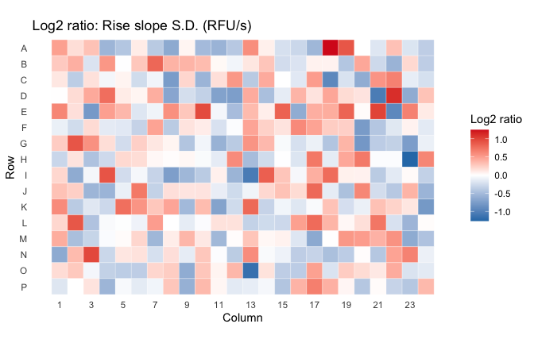

```r
plot_parameter <- "Rise slope S.D. (RFU/s)"

plot_df <- data.frame(
  Well = baseline_plate@wellIds,
  Row = substr(baseline_plate@wellIds, 1, 1),
  Column = as.integer(sub("^[A-P]", "", baseline_plate@wellIds)),
  Value = as.numeric(log2ratio[[plot_parameter]])
)

ggplot(plot_df, aes(x = Column, y = Row, fill = Value)) +
  geom_tile(color = "white", linewidth = 0.1) +
  coord_fixed() +
  scale_y_discrete(limits = rev(LETTERS[1:16])) +
  scale_x_continuous(breaks = seq(1, 24, by = 2)) +
  scale_fill_gradient2(
    low = "#2C7BB6",
    mid = "white",
    high = "#D7191C",
    midpoint = 0,
    na.value = "grey90"
  ) +
  labs(
    title = paste("Log2 ratio:", plot_parameter),
    x = "Column",
    y = "Row",
    fill = "Log2 ratio"
  ) +
  theme_minimal(base_size = 11) +
  theme(panel.grid = element_blank())
```

## Reuse the Workflow

The same workflow can be applied to the Stemonix May 2022 files in `inst/extdata/Stemonix_05_2022` by swapping the file paths:

```r
stemonix_manifest <- data.frame(file = list.files(stemonix_dir))
knitr::kable(stemonix_manifest)
```

| file |
| --- |
| 05272022_Stemonix_plate3_60mins_n001_Pro2.statAll |
| 05272022_Stemonix_plate3_BL_n001_Pro2.statAll |
| CalFlux_Parameter_selection_MOE9_60_PC.xlsx |
| Stemonix_MOE9_60_PC_ON2_Full.csv |

For full report generation, use a patched manifest with `processCalFluxData()`. For focused exploratory work, parse the `statAll` files, attach the plate map, and call the lower-level QC and transformation helpers shown above.